# Count line length within polygons

Density is the ratio of the the amount of something within a polygon to the area of the polygon. This page demonstrates how find the length of line within each polygon in a layer.

# Required packages

This example uses the following packages

```r
library(tidyverse)
library(sf)
library(knitr)
library(tigris)
```

# Load some sample data

I’ll start by downloading and loading a layer of census tracts and a layer of streets for Somerville, Massachusetts.

```r
somerville <- places(state = "MA") %>%
  filter(NAME == "Somerville")

tracts <- tracts(state = "MA", county = "Middlesex") %>%
  st_filter(somerville, .predicate = st_within) %>%
  select(NAMELSAD)

streets <- roads(state = "MA", county = "Middlesex") %>%
  st_intersection(somerville) %>%
  select(FULLNAME)
```

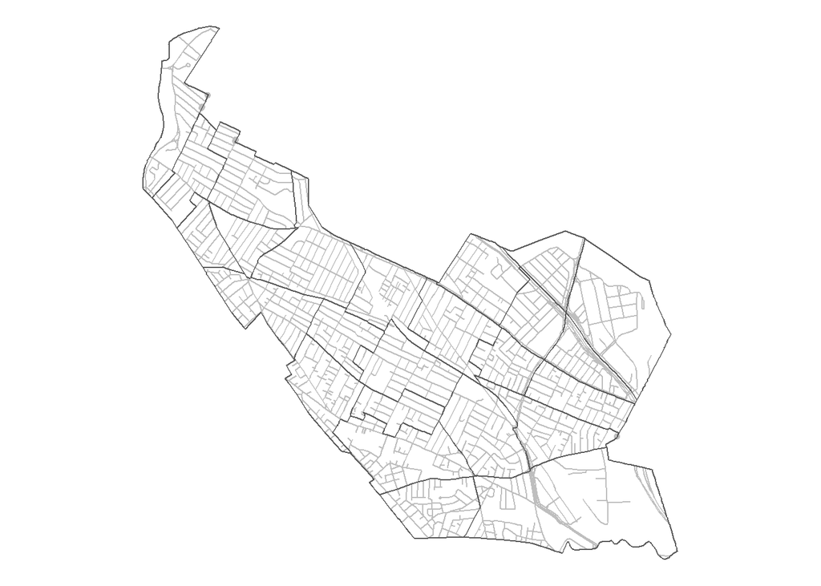

```r
ggplot() +
  geom_sf(data = streets,
          color = "gray") +
  geom_sf(data = tracts,
          fill = NA) +
  theme_void()
```

# Split lines into polygons

`st_intersection` will split the lines among a layer of polygons and add the attributes of the polygon containing each line to the line attributes.

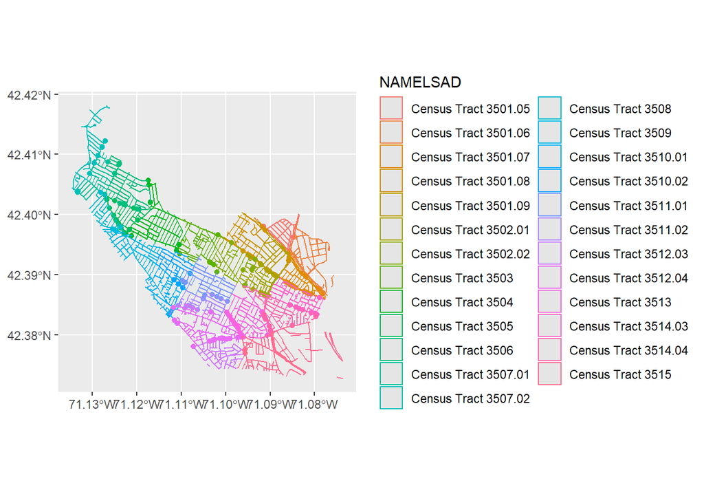

```r
streets_by_tract <- st_intersection(streets, tracts)

ggplot(streets_by_tract) +
  geom_sf(aes(color = NAMELSAD))
```

# Calculate the length of lines

Now you can use `st_length()` to calculate the length of each segment. You should transform your data to a projected coordinate system first (using `st_transform`) and you should use `as.numeric()` so the resulting variable will be a normal number rather than a `units`-type variable.

```r
MA_st_plane <- "+proj=lcc +lat_1=42.68333333333333 +lat_2=41.71666666666667 +lat_0=41 +lon_0=-71.5 +x_0=200000.0001016002 +y_0=750000 +ellps=GRS80 +towgs84=0,0,0,0,0,0,0 +to_meter=0.3048006096012192 +no_defs"

streets_by_tract <- streets_by_tract %>%
  st_transform(MA_st_plane) %>%
  mutate(segment_length = as.numeric(st_length(.)))
```

# Aggregate to polygons

Now you can drop the geometry and add up the total line length within each polygon.

```r
length_by_tract <- streets_by_tract %>%
  st_drop_geometry() %>%
  group_by(NAMELSAD) %>%
  summarise(total_street_ft = sum(segment_length))
```

# Join to polygons

Finally, you can join the street lengths to the original polygon layer

```r
tracts <- tracts %>%
  left_join(length_by_tract)
tracts %>%
  head() %>%
  kable()
```

| NAMELSAD | total_street_ft | geometry |
| --- | --- | --- |
| Census Tract 3505 | 14161.25 | MULTIPOLYGON (((-71.12707 4… |
| Census Tract 3506 | 28557.16 | MULTIPOLYGON (((-71.12725 4… |
| Census Tract 3508 | 14485.62 | MULTIPOLYGON (((-71.1307 42… |
| Census Tract 3509 | 31172.56 | MULTIPOLYGON (((-71.12741 4… |
| Census Tract 3513 | 30721.61 | MULTIPOLYGON (((-71.10005 4… |
| Census Tract 3515 | 68004.76 | MULTIPOLYGON (((-71.09738 4… |